# Data Dictionary

2022-11-29

import dataset:

```r
stage2<-read.csv("export_dataframe_stage2.csv")
```

### rain_24_hours

rain over 24 hour period

- 4 distinct status: `Intermittent Rain`, `Heavy Rain`, `Steady Rain`, `None`
- All strings, 0 non-character inputs
- 42222 empty values

```r
# display unique values
unique(stage2$rain_24_hours)

sum(!is.character(stage2$rain_24_hours))

# counting for the number of null/error values
count_empty = 0

for (i in 1:length(stage2$rain_24_hours)){
  if (stage2$rain_24_hours[i] == ""){
    count_empty = count_empty +1
  }
}

paste0("rain_24_hours has ", count_empty, " empty values")
```

[output not shown]

### weather

description of weather

- 5 distinct classifications “Clear, Steady, Overcast, Heavy, Intermittent”
- there appears to be input error since each classification has twin with semicolon
- 23595 empty values

```r
# display unique values
unique(stage2$weather)

# counting null/error values
count_empty = 0

for (i in 1:length(stage2$weather)){
  if (stage2$weather[i] == ""){
    count_empty = count_empty +1
  }
}

paste0("weather has ", count_empty, " empty values")
```

[output not shown]

### rain_hours

- Numeric values indicating total amount of hours of rain
- 26305 NAs
- 221 sites with 0 rain seems to be input error
- histogram shows highly skewed data, many potential outliers
- summary supports skewedness and potential outliers…
- median of 24 and mean od 47.95 very notable
- mean is also greater than 3rd quartile… outliers!!
- 2871 places with over 100 hours of rain

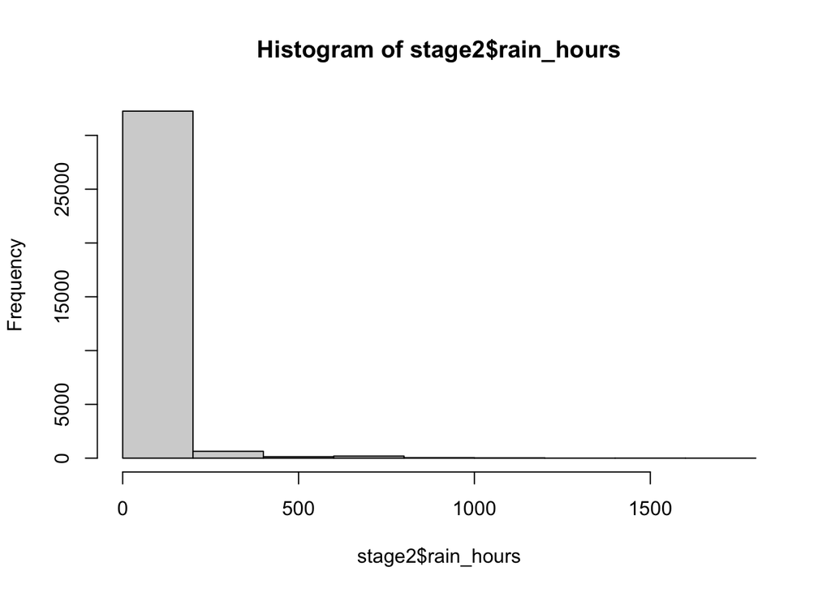

```r
length(!is.numeric(stage2$rain_hours)) # row name should be only non-numeric
subset(stage2, !is.numeric(rain_hours)) # no non-numerics confirmed

count_NA <-  sum(is.na(stage2$rain_hours))

paste0("rain_hours has ", count_NA, " NAs")

hist(stage2$rain_hours, breaks = 10) # data very skewed
```

```r
summary(stage2$rain_hours)

nrow(subset(stage2, rain_hours == 0)) # apparently 221 sites with 0 rain
nrow(subset(stage2, rain_hours > 100)) # 2871 places with over 100 hours of rain
```

[output not shown]

## rain_inches

- Numeric with amount of rain in inches (site average?)
- Lots of errors here…
- 22929 NAs
- 23333 entries with 0 inches rain (no empty values, though)
- entry with input 3031 is error

```r
class(stage2$rain_inches)
```

```
## [1] "numeric"
```

```r
length(!is.numeric(stage2$rain_inches))# no non-numeric values beside col name
```

```
## [1] 1
```

```r
summary(stage2$rain_inches)
```

```
##     Min.  1st Qu.   Median     Mean  3rd Qu.     Max.     NA's
##    0.000    0.000    0.000    0.458    0.160 3031.000    22929
```

```r
nrow(subset(stage2, rain_inches == 0))
```

```
## [1] 23333
```

```r
sum(is.na(stage2$rain_inches)) # 22929 NAs
```

```
## [1] 22929
```

```r
paste("There are", nrow(subset(stage2, rain_inches == ""))," empty values")
```

```
## [1] "There are 0  empty values"
```

```r
paste0("There are ", sum(is.na(stage2$rain_inches)), " NAs")
```

```
## [1] "There are 22929 NAs"
```

```r
paste("There are", nrow(subset(stage2, rain_inches == 0)) ," values recorded as 0.  This must be input error.")
```

```
## [1] "There are 23333  values recorded as 0.  This must be input error."
```

## distance

```r
class(stage2$distance)
```

```
## [1] "numeric"
```

```r
length(!is.numeric(stage2$distance))# no non-numeric values beside col name
```

```
## [1] 1
```

```r
summary(stage2$distance)
```

```
##    Min. 1st Qu.  Median    Mean 3rd Qu.    Max.    NA's
##     0.0     1.0     6.0    12.9    15.0   400.0   53956
```

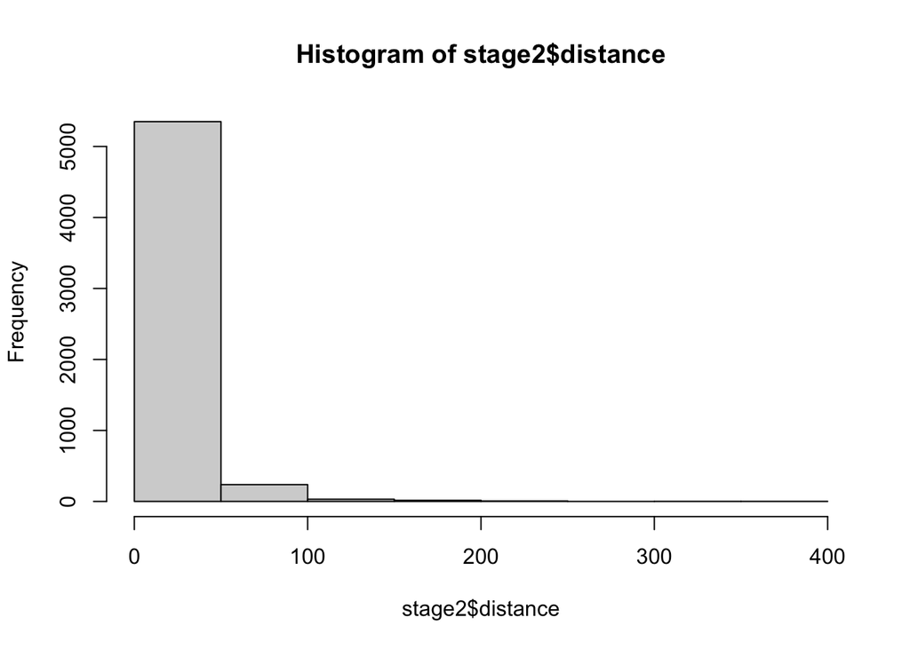

```r
hist(stage2$distance)
```

```r
nrow(subset(stage2, distance == 0))
```

```
## [1] 316
```

```r
sum(is.na(stage2$distance))
```

```
## [1] 53956
```

```r
paste("There are", nrow(subset(stage2, distance == ""))," empty values")
```

```
## [1] "There are 0  empty values"
```

```r
paste0("There are ", sum(is.na(stage2$distance)), " NAs")
```

```
## [1] "There are 53956 NAs"
```

```r
paste("There are", nrow(subset(stage2, distance == 0)) ," values recorded as 0")
```

```
## [1] "There are 316  values recorded as 0"
```

```r
paste("There are", nrow(subset(stage2, distance > 100)) ," values recorded over 100")
```

```
## [1] "There are 55  values recorded over 100"
```